# Differentiated Signal Response Task

## Dependencies

Load all required R libraries.

```r
library(ggplot2)  # (Wickham, 2009)
library(dplyr)    # (Wickham et al., 2018)
library(cowplot)  # (Wilke, 2018)
library(viridis)  # (Garnier, 2018)
library(eulerr)
library(tidyr)
```

## Setup

Load data, initial data cleanup, global settings.

```r
data_loc <- "../data/mc-reg/max_fit_orgs.csv"
data <- read.csv(data_loc, na.strings="NONE")
data <- subset(data, select = -c(program))

# Specify factors.
data$matchbin_thresh <- factor(data$matchbin_thresh,
                                     levels=c(0, 25, 50, 75))

data$TAG_LEN <- factor(data$TAG_LEN,
                       levels=c(32, 64, 128))
data$DEME_SIZE <- data$DEME_HEIGHT*data$DEME_WIDTH
data$relies_on_reg <- factor(data$relies_on_reg, levels=c(0, 1))
data$relies_on_mem <- factor(data$relies_on_mem, levels=c(0, 1))
data$relies_on_msg <- factor(data$relies_on_msg, levels=c(0, 1))
data$relies_on_imprinting <- factor(data$relies_on_imprinting, levels=c(0, 1))
data$relies_on_repro_tag <- factor(data$relies_on_repro_tag, levels=c(0, 1))
# Define function to summarize regulation/memory configurations.
get_con <- function(reg, mem) {
  if (reg == "0" && mem == "0") {
    return("none")
  } else if (reg == "0" && mem=="1") {
    return("memory")
  } else if (reg=="1" && mem=="0") {
    return("regulation")
  } else if (reg=="1" && mem=="1") {
    return("both")
  } else {
    return("UNKNOWN")
  }
}
# Specify experimental condition for each datum.
data$condition <- mapply(get_con, data$USE_FUNC_REGULATION, data$USE_GLOBAL_MEMORY)
data$condition <- factor(data$condition, levels=c("regulation", "memory", "none", "both"))

data$stochastic <- 1 - data$consistent # Does this program rely on a stochastic strategy?

# Settings for statistical analyses.
alpha <- 0.05
correction_method <- "bonferroni"
theme_set(theme_cowplot())
```

## Multicell Fitness

Here, we give the raw task scores (log scale) for the highest-fitness organism from each run across all environments/conditions. Note that the axes are different for each multicell size.

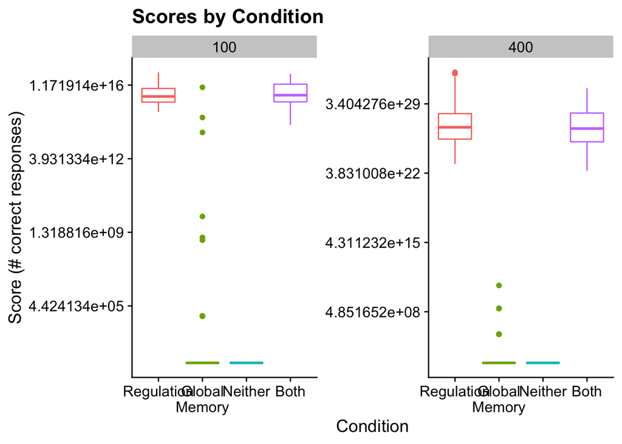

```r
# From: https://stackoverflow.com/questions/23901907/create-a-log-sequence-across-multiple-orders-of-magnitude
lseq <- function(from=1, to=100000, length.out=6) {
  return(exp(seq(log(from), log(to), length.out = length.out)))
}

ggplot(data, aes(x=condition, y=score, color=condition)) +
  geom_boxplot() +
  ggtitle("Scores by Condition") +
  xlab("Condition") +
  ylab("Score (# correct responses)") +
  scale_color_discrete(breaks=c("regulation", "memory", "none", "both"),
                   labels=c("Regulation", "Global Memory", "Neither", "Both")) +
  scale_x_discrete(breaks=c("regulation", "memory", "none", "both"),
                   labels=c("Regulation", "Global\nMemory", "Neither", "Both")) +
  scale_y_continuous(trans="log") +
  theme(legend.position="none") +
  facet_wrap(~DEME_SIZE, scales="free") +
  ggsave("./imgs/mc-reg-scores.png", width=16,height=8)
```

## What do multi-cells rely on to differentiate cell responses?

### Multicell size = 10x10

Maximum of 100 cells per multicell and 10 possible responses.

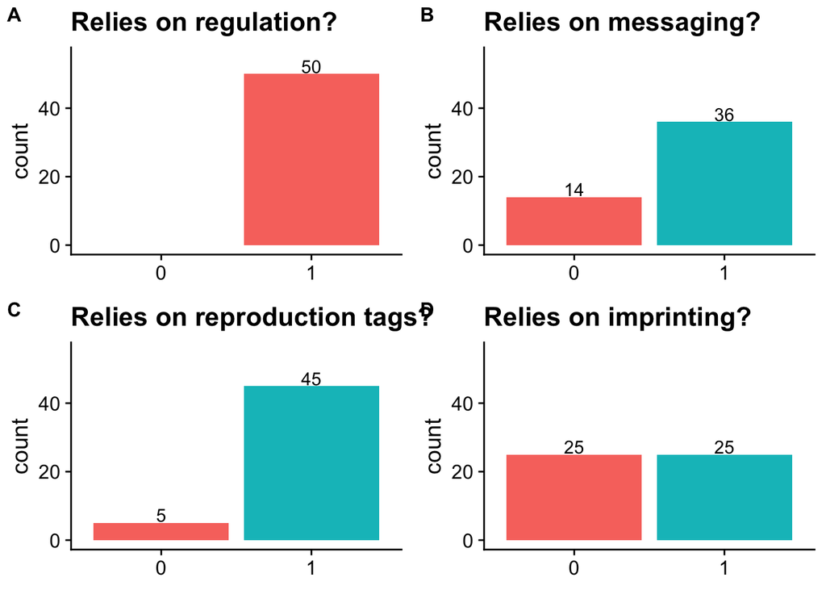

```r
reg_data <- filter(data, condition=="both" & DEME_SIZE==100)

msg_p <- ggplot(reg_data, aes(x=relies_on_msg, fill=relies_on_msg)) +
            geom_bar() +
            geom_text(stat='count', aes(label=..count..), vjust=-.1) +
            ylim(0, 55) +
            ggtitle("Relies on messaging?") +
            theme(legend.position="none",axis.title.x=element_blank())

imp_p <- ggplot(reg_data, aes(x=relies_on_imprinting, fill=relies_on_imprinting)) +
            geom_bar() +
            geom_text(stat='count', aes(label=..count..), vjust=-.1) +
            ylim(0, 55) +
            ggtitle("Relies on imprinting?") +
            theme(legend.position="none",axis.title.x=element_blank())

tag_p <- ggplot(reg_data, aes(x=relies_on_repro_tag, fill=relies_on_repro_tag)) +
            geom_bar() +
            geom_text(stat='count', aes(label=..count..), vjust=-.1) +
            ylim(0, 55) +
            ggtitle("Relies on reproduction tags?") +
            theme(legend.position="none",axis.title.x=element_blank())

reg_p <- ggplot(reg_data, aes(x=relies_on_reg, fill=relies_on_reg)) +
            geom_bar() +
            geom_text(stat='count', aes(label=..count..), vjust=-.1) +
            ylim(0, 55) +
            ggtitle("Relies on regulation?") +
            scale_x_discrete(limits=c("0", "1"), labels=c("0", "1")) +
            theme(legend.position="none",axis.title.x=element_blank())


grid <- plot_grid(reg_p,msg_p,tag_p,imp_p, labels = c('A', 'B', 'C', 'D'), label_size = 12)
print(grid)
```

```r
save_plot("./imgs/multi-cell-differentiation-strategy-10x10.png", grid, base_height=6, base_width=8)
```

What is the strategy breakdown (in more detail)?

Each genotype may rely on multiple coordination strategies (i.e., messaging, imprinting, reproduction tags, etc) simultaneously. Here, we use a euler diagram to give a more detailed breakdown of coordination strategies.

```r
usage_data <- filter(data, condition=="both" & DEME_SIZE==100)
usage_data <- subset(usage_data, select=c(relies_on_msg,relies_on_imprinting,relies_on_repro_tag,relies_on_mem))
usage_data$msg <- usage_data$relies_on_msg == "1"
usage_data$repro_tag <- usage_data$relies_on_repro_tag == "1"
usage_data$imprinting <- usage_data$relies_on_imprinting == "1"
usage_data$mem <- usage_data$relies_on_mem == "1"
usage_data$none <- !usage_data$msg & !usage_data$repro_tag & !usage_data$imprinting & !usage_data$mem
usage_data <- subset(usage_data, select=c(msg, repro_tag, imprinting, mem, none))
euler(usage_data)
```

```
##                                   original fitted residuals regionError
## msg                                      1      1         0       0.001
## repro_tag                                7      7         0       0.006
## imprinting                               1      1         0       0.001
## mem                                      0      0         0       0.000
## none                                     1      1         0       0.001
## msg&repro_tag                           14     14         0       0.012
## msg&imprinting                           2      0         2       0.040
## msg&mem                                  0      0         0       0.000
## msg&none                                 0      0         0       0.000
## repro_tag&imprinting                     4      4         0       0.003
## repro_tag&mem                            1      1         0       0.001
## repro_tag&none                           0      0         0       0.000
## imprinting&mem                           0      0         0       0.000
## imprinting&none                          0      0         0       0.000
## mem&none                                 0      0         0       0.000
## msg&repro_tag&imprinting                18     18         0       0.015
## msg&repro_tag&mem                        1      1         0       0.001
## msg&repro_tag&none                       0      0         0       0.000
## msg&imprinting&mem                       0      0         0       0.000
## msg&imprinting&none                      0      0         0       0.000
## msg&mem&none                             0      0         0       0.000
## repro_tag&imprinting&mem                 0      0         0       0.000
## repro_tag&imprinting&none                0      0         0       0.000
## repro_tag&mem&none                       0      0         0       0.000
## imprinting&mem&none                      0      0         0       0.000
## msg&repro_tag&imprinting&mem             0      0         0       0.000
## msg&repro_tag&imprinting&none            0      0         0       0.000
## msg&repro_tag&mem&none                   0      0         0       0.000
## msg&imprinting&mem&none                  0      0         0       0.000
## repro_tag&imprinting&mem&none            0      0         0       0.000
## msg&repro_tag&imprinting&mem&none        0      0         0       0.000
##
## diagError: 0.04
## stress:    0.007
```

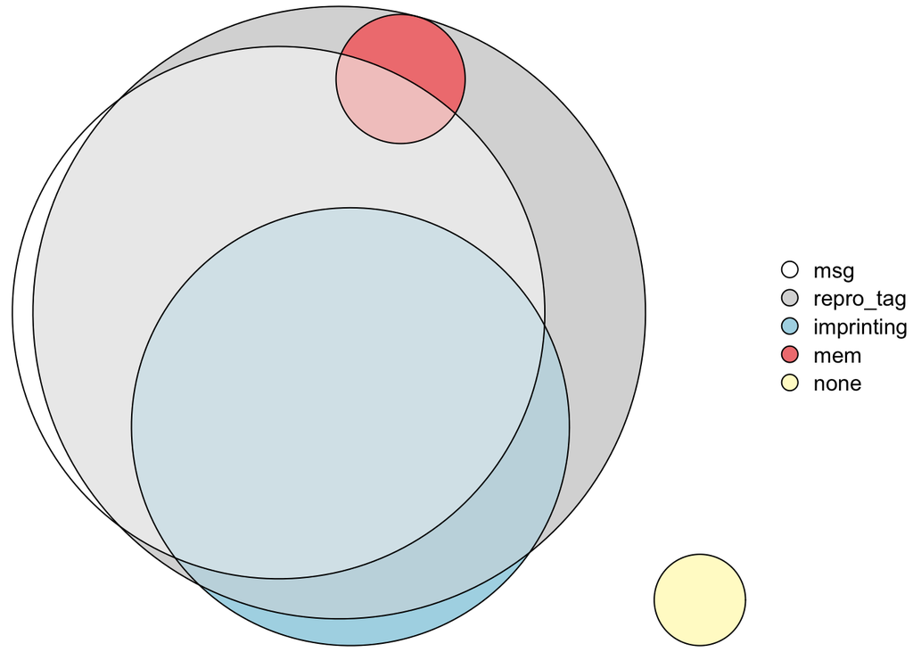

```r
e <- plot(euler(usage_data), legend=TRUE)
save_plot("./imgs/multicell-strategies-breakdown-10x10.png", e, base_width=4, base_height=4)
e
```

Takeaways:

- 1 genotype uses a ‘none’ strategy. I.e., it uses none of the available *explicit* mechanisms for coordination. My hypothesis is that this genotype is exploiting the timing of the development phase of this experiment. Cell births that occur later during development have fewer time steps to execute than cells born early during development, allowing multicells to leverage relative execution timing to differentiate.
- The most common combination of mechanisms (18) uses all three of: messaging, reproduction tags, and regulation imprinting for differentiation
- The second-most-common combination of mechanisms (14) uses messaging and reproduction tag control.

What does fitness look like for genotypes relying on different mechanisms?

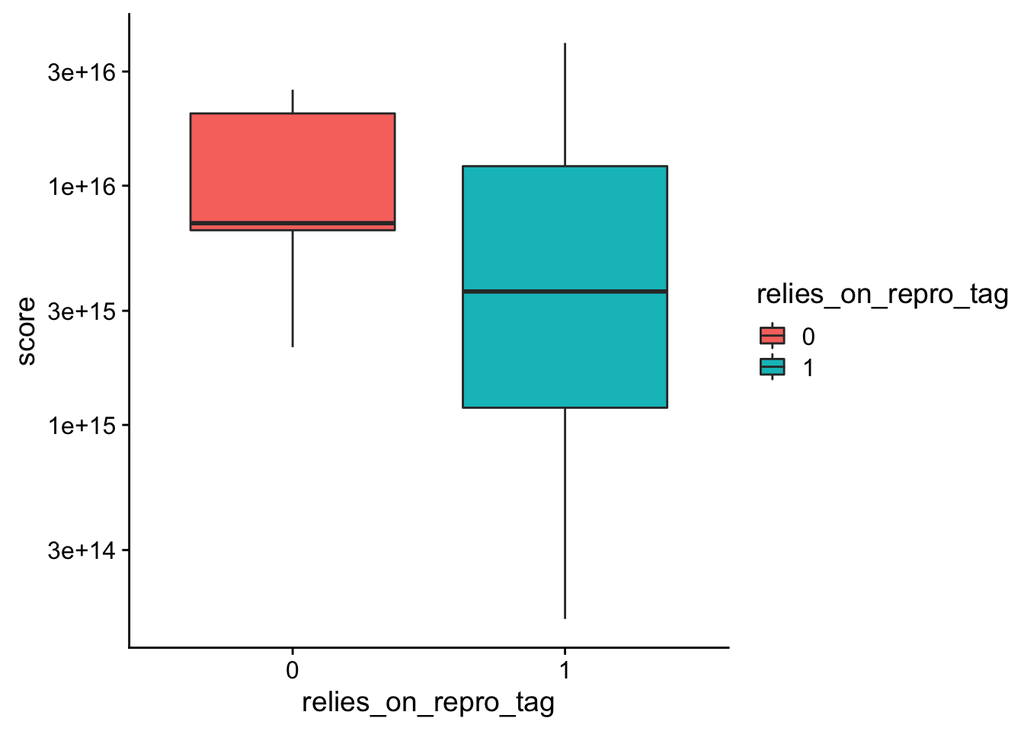

```r
ggplot(reg_data, aes(x=relies_on_repro_tag, y=score, fill=relies_on_repro_tag)) +
  scale_y_continuous(trans="log10") +
  geom_boxplot()
```

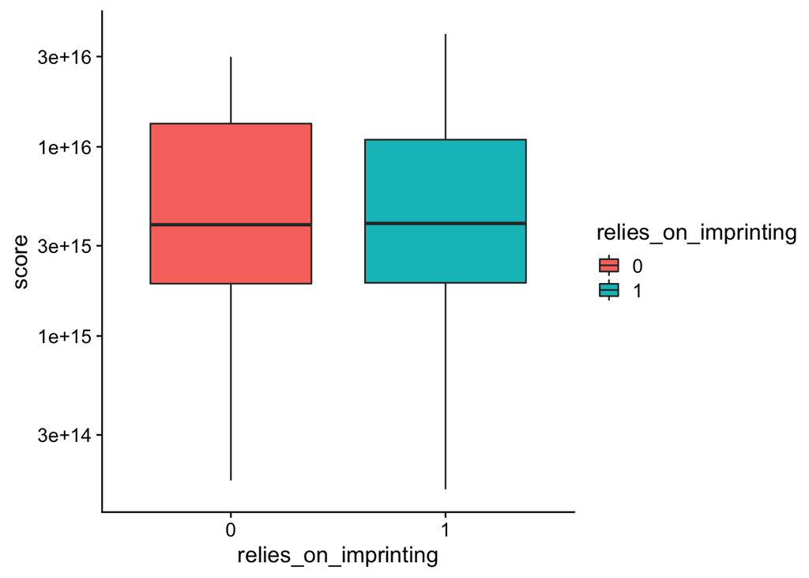

```r
ggplot(reg_data, aes(x=relies_on_imprinting, y=score, fill=relies_on_imprinting)) +
  scale_y_continuous(trans="log10") +
  geom_boxplot()
```

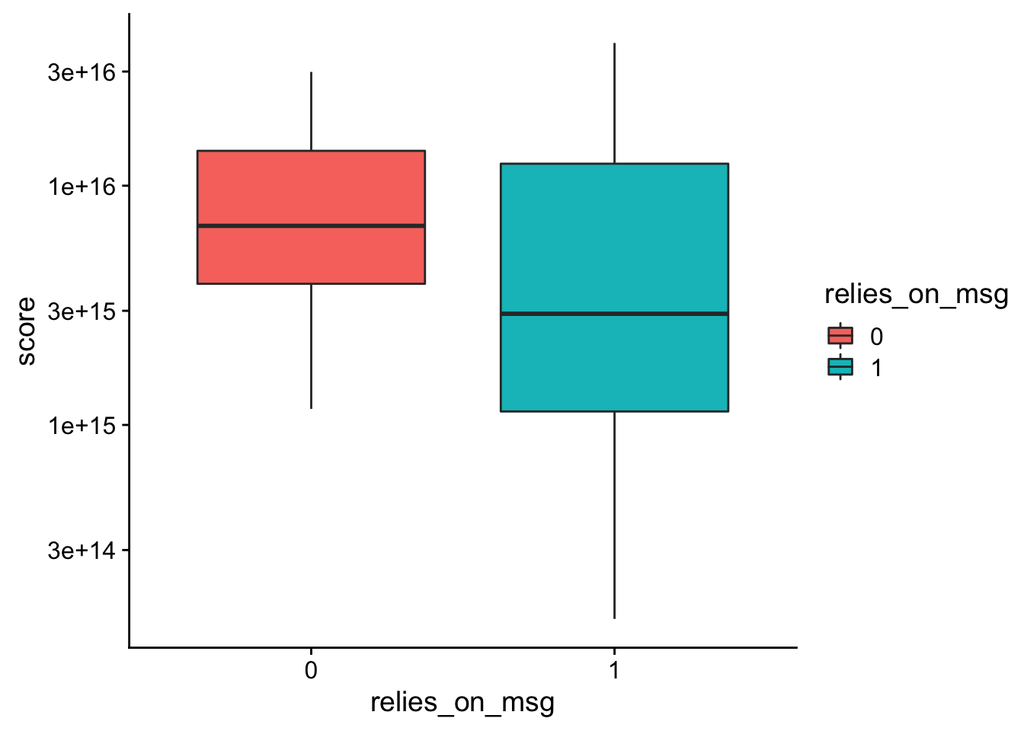

```r
ggplot(reg_data, aes(x=relies_on_msg, y=score, fill=relies_on_msg)) +
  scale_y_continuous(trans="log10") +
  geom_boxplot()
```

Not sure we can read much into these fitness differentials. A few issues here (nont balanced sets, strategies rely on more than one mechanisms, etc).

### Multicell size = 20x20

Maximum of 400 cells per multicell, 20 possible cellular responses.

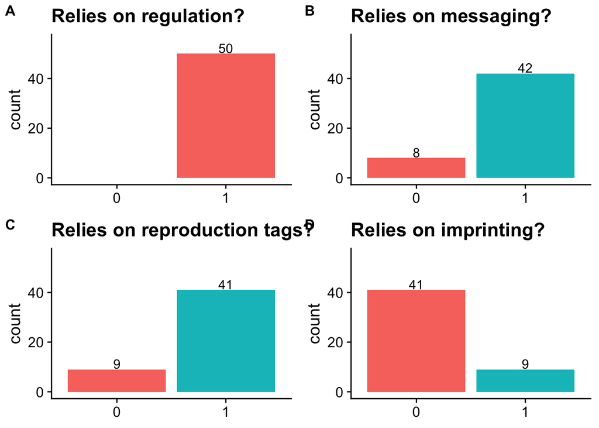

```r
reg_data <- filter(data, condition=="both" & DEME_SIZE==400)

msg_p <- ggplot(reg_data, aes(x=relies_on_msg, fill=relies_on_msg)) +
            geom_bar() +
            geom_text(stat='count', aes(label=..count..), vjust=-.1) +
            ylim(0, 55) +
            ggtitle("Relies on messaging?") +
            theme(legend.position="none",axis.title.x=element_blank())

imp_p <- ggplot(reg_data, aes(x=relies_on_imprinting, fill=relies_on_imprinting)) +
            geom_bar() +
            geom_text(stat='count', aes(label=..count..), vjust=-.1) +
            ylim(0, 55) +
            ggtitle("Relies on imprinting?") +
            theme(legend.position="none",axis.title.x=element_blank())

tag_p <- ggplot(reg_data, aes(x=relies_on_repro_tag, fill=relies_on_repro_tag)) +
            geom_bar() +
            geom_text(stat='count', aes(label=..count..), vjust=-.1) +
            ylim(0, 55) +
            ggtitle("Relies on reproduction tags?") +
            theme(legend.position="none",axis.title.x=element_blank())

reg_p <- ggplot(reg_data, aes(x=relies_on_reg, fill=relies_on_reg)) +
            geom_bar() +
            geom_text(stat='count', aes(label=..count..), vjust=-.1) +
            ylim(0, 55) +
            ggtitle("Relies on regulation?") +
            scale_x_discrete(limits=c("0", "1"), labels=c("0", "1")) +
            theme(legend.position="none",axis.title.x=element_blank())


grid <- plot_grid(reg_p,msg_p,tag_p,imp_p, labels = c('A', 'B', 'C', 'D'), label_size = 12)
print(grid)
```

```r
save_plot("./imgs/multi-cell-differentiation-strategy-20x20.png", grid, base_height=6, base_width=8)
```

What is the strategy breakdown (in more detail)?

```r
usage_data <- filter(data, condition=="both" & DEME_SIZE==400)
usage_data <- subset(usage_data, select=c(relies_on_msg,relies_on_imprinting,relies_on_repro_tag,relies_on_mem))
usage_data$msg <- usage_data$relies_on_msg == "1"
usage_data$repro_tag <- usage_data$relies_on_repro_tag == "1"
usage_data$imprinting <- usage_data$relies_on_imprinting == "1"
usage_data$mem <- usage_data$relies_on_mem == "1"
usage_data$none <- !usage_data$msg & !usage_data$repro_tag & !usage_data$imprinting & !usage_data$mem
usage_data <- subset(usage_data, select=c(msg, repro_tag, imprinting, mem, none))
euler(usage_data)
```

```
##                                   original fitted residuals regionError
## msg                                      7      7         0           0
## repro_tag                                4      4         0           0
## imprinting                               0      0         0           0
## mem                                      0      0         0           0
## none                                     2      2         0           0
## msg&repro_tag                           24     24         0           0
## msg&imprinting                           0      0         0           0
## msg&mem                                  0      0         0           0
## msg&none                                 0      0         0           0
## repro_tag&imprinting                     1      1         0           0
## repro_tag&mem                            1      1         0           0
## repro_tag&none                           0      0         0           0
## imprinting&mem                           0      0         0           0
## imprinting&none                          0      0         0           0
## mem&none                                 0      0         0           0
## msg&repro_tag&imprinting                 8      8         0           0
## msg&repro_tag&mem                        3      3         0           0
## msg&repro_tag&none                       0      0         0           0
## msg&imprinting&mem                       0      0         0           0
## msg&imprinting&none                      0      0         0           0
## msg&mem&none                             0      0         0           0
## repro_tag&imprinting&mem                 0      0         0           0
## repro_tag&imprinting&none                0      0         0           0
## repro_tag&mem&none                       0      0         0           0
## imprinting&mem&none                      0      0         0           0
## msg&repro_tag&imprinting&mem             0      0         0           0
## msg&repro_tag&imprinting&none            0      0         0           0
## msg&repro_tag&mem&none                   0      0         0           0
## msg&imprinting&mem&none                  0      0         0           0
## repro_tag&imprinting&mem&none            0      0         0           0
## msg&repro_tag&imprinting&mem&none        0      0         0           0
##
## diagError: 0
## stress:    0
```

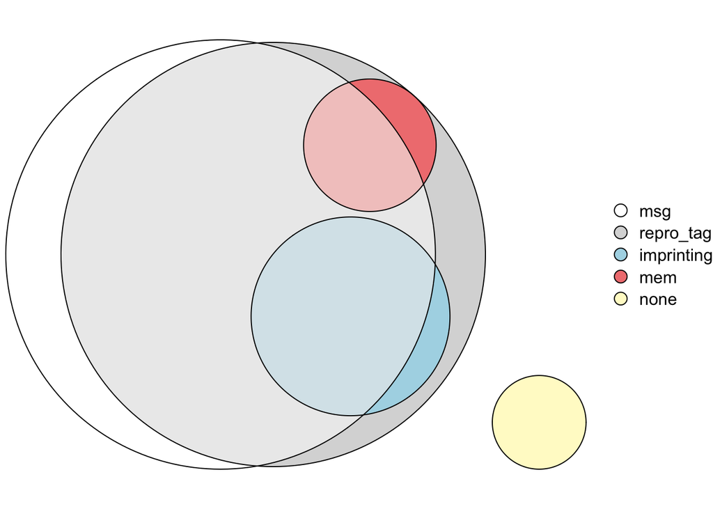

```r
e <- plot(euler(usage_data), legend=TRUE)
save_plot("./imgs/multicell-strategies-breakdown-20x20.png", e, base_width=4, base_height=4)
e
```

What does fitness look like for genotypes relying on different mechanisms?

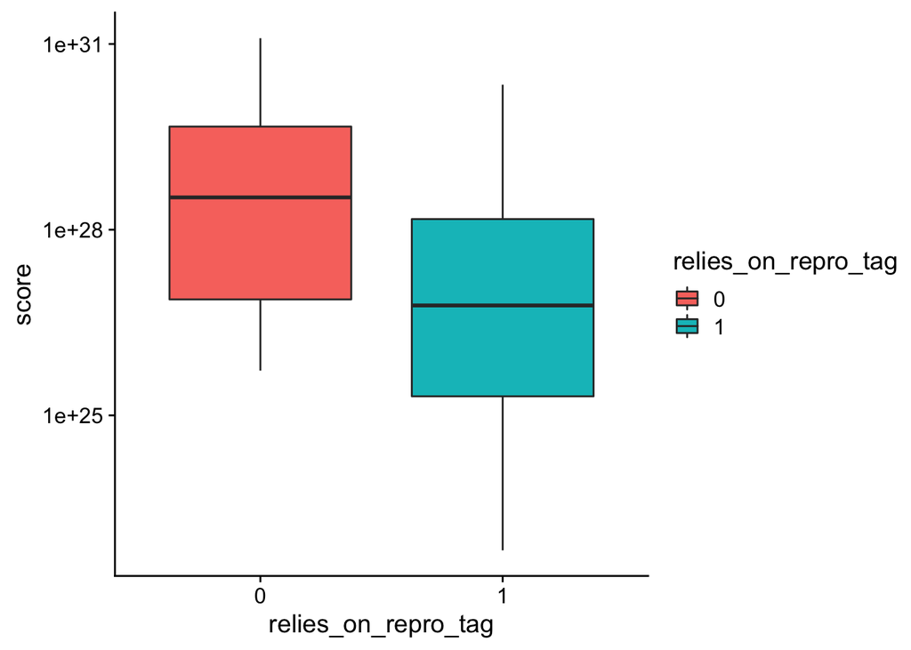

```r
ggplot(reg_data, aes(x=relies_on_repro_tag, y=score, fill=relies_on_repro_tag)) +
  scale_y_continuous(trans="log10") +
  geom_boxplot()
```

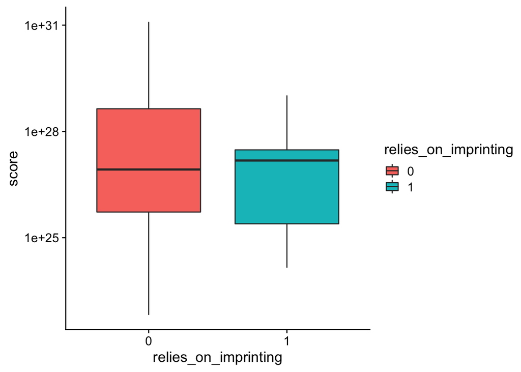

```r
ggplot(reg_data, aes(x=relies_on_imprinting, y=score, fill=relies_on_imprinting)) +
  scale_y_continuous(trans="log10") +
  geom_boxplot()
```

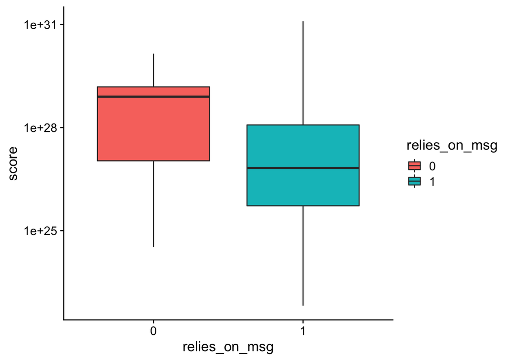

```r
ggplot(reg_data, aes(x=relies_on_msg, y=score, fill=relies_on_msg)) +
  scale_y_continuous(trans="log10") +
  geom_boxplot()
```